# STAT385 Notes Week 7

## A graphing template

- The following code segment is a reusable template for making graphs with `ggplot2`

```r
ggplot(data = <DATA>)
  <GEOM_FUNCTION>(mapping = aes (<MAPPINGS>))
```

## The `geom` function

- There are many `geom()` functions in ggplot2: `geom_boxplot()`, `geom_line()`, etc.
- Each `geom()` function takes a `mapping` argument. This defines how variables in your dataset are mapped to visual properties
  - The `mapping` argument is always paired with `aes()`
  - The `x` and `y` arguments of `aes()` set the axes
  - `ggplot2` looks for the mapped variables in teh data argument

### Examples

- **Example 1:** make a scatterplot of `hwy` vs `cyl`.
- **Example 2:** make a scatterplot of `class` vs `drv`.

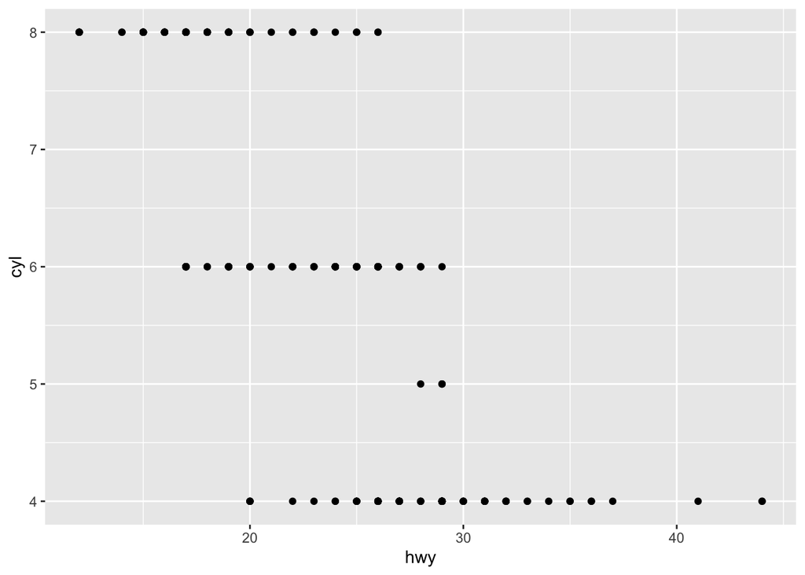

```r
# Example 1: scatterplot of `hwy` vs `cyl`.
ggplot(data = mpg) +
  geom_point(mapping = aes(x = hwy, y = cyl))
```

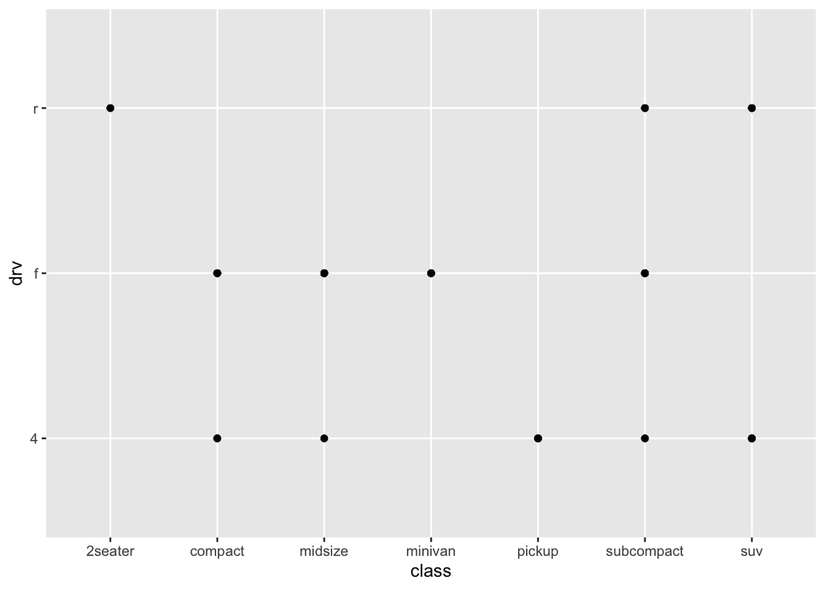

```r
# Example 2: scatterplot of `class` vs `drv`.
ggplot(data = mpg) +
  geom_point(mapping = aes(x = class, y = drv))
```

## Aesthetic Mappings

- Aesthetic mappings use the `aes()` function
- Aesthetics are the visual properties of of the objects in your plot
- This could be the size, shape, and color of your points

### Add color to your plot

- With `aes(..., color = class)`, `ggplot2` will automatically assign a unique level of the aesthetic (here a unique color) to each unique value of the variable (here `class`), a process known as **scaling**.
- `ggplot2` will also add a legend that explains which levels correspond to which values.

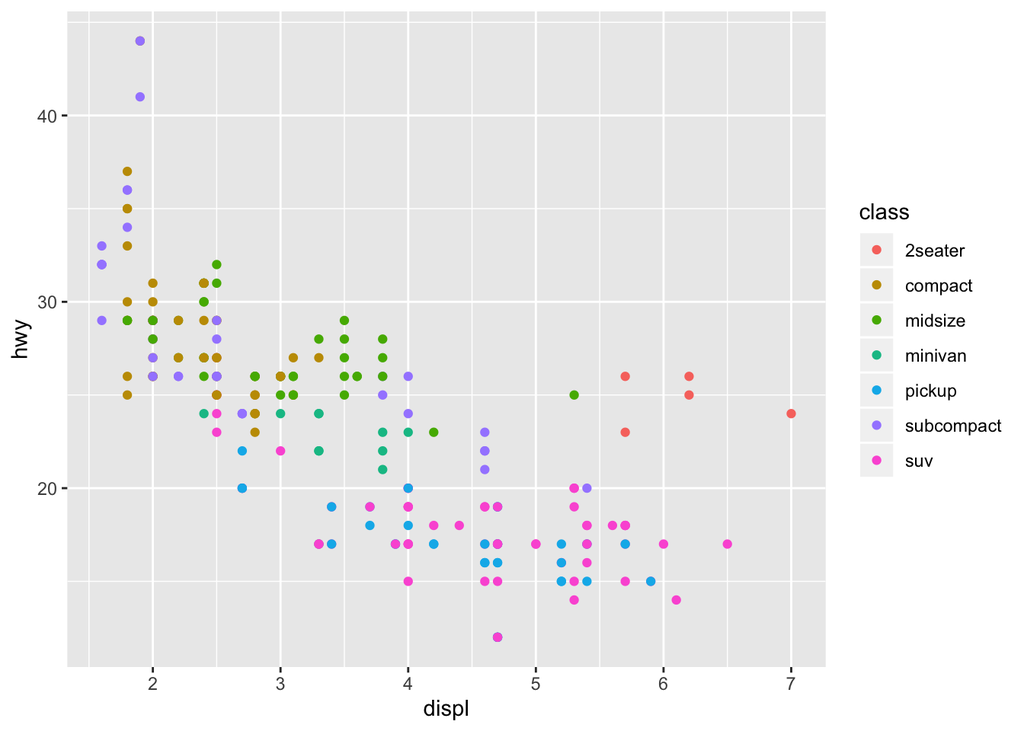

```r
ggplot(data = mpg) +
  geom_point(mapping = aes(x = displ, y = hwy, color = class))
```

- Now, what’s if you don’t want to color the points by class, you just want all the points to be blue!
  - Let’s try changing class to “blue”.

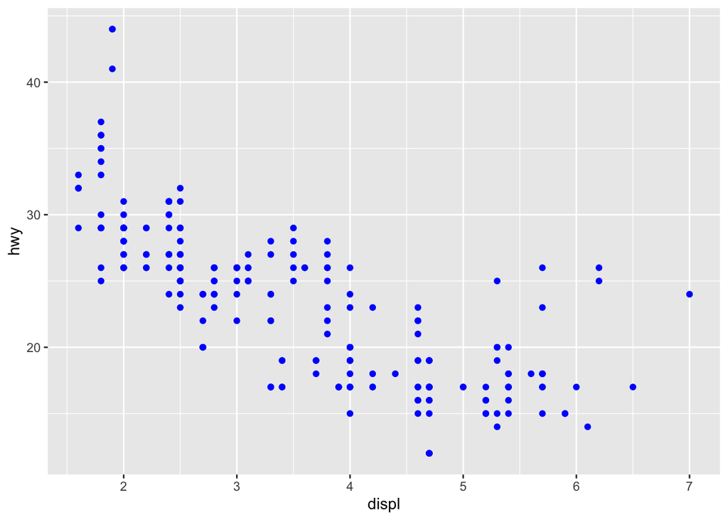

```r
ggplot(data = mpg) +
  geom_point(mapping = aes(x = displ, y = hwy), color = "blue")
```

- This goes outside of the `aes()` argument.
  - We are manually setting the color to blue, not mapping it to any data

### Change the shape of your points

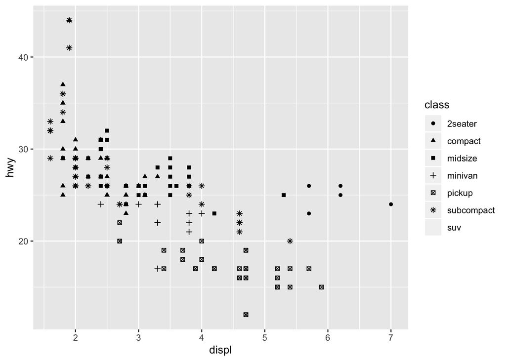

```r
ggplot(data = mpg) +
  geom_point(mapping = aes(x = displ, y = hwy, shape = class))
```

- `suv` is not shown because the shape palette default can only handle 6 descrete values, and `class` has 7 values. In order to have 7 classes, we would have to manually set shapes.
- We can manually set shape similar to how we manyally set color:

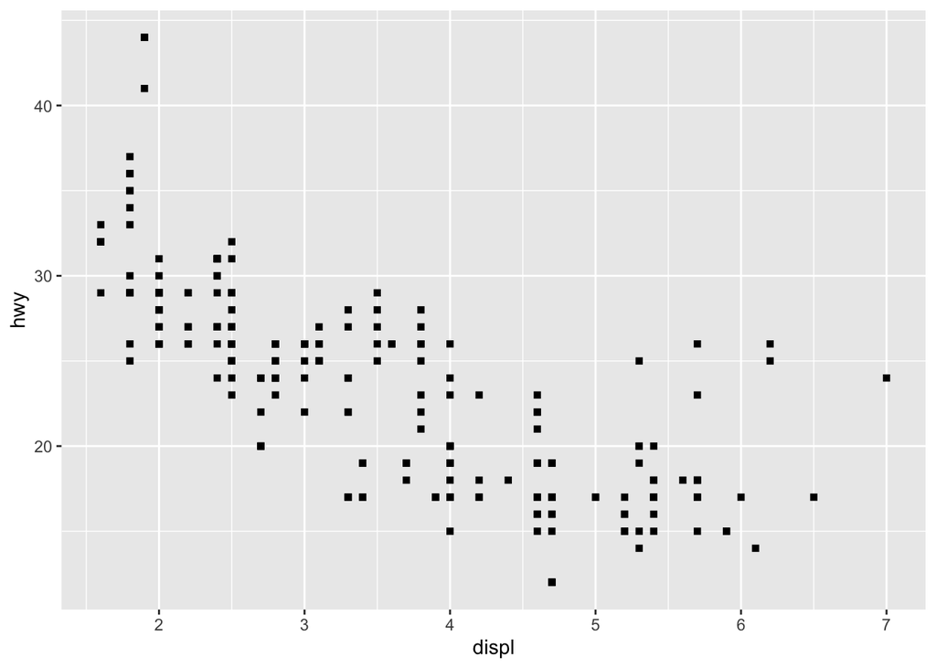

```r
ggplot(data = mpg) +
  geom_point(mapping = aes(x = displ, y = hwy), shape = 15)
```

### Change the transparency of points

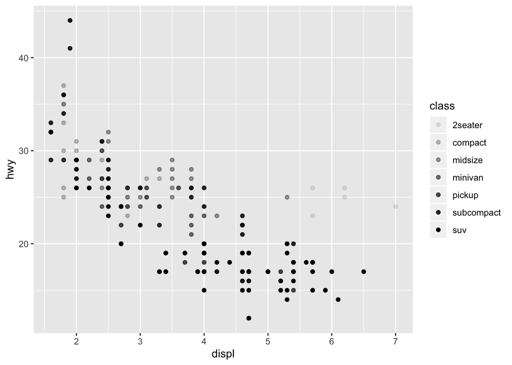

```r
ggplot(data = mpg) +
  geom_point(mapping = aes(x = displ, y = hwy, alpha = class))
```

- Let’s try setting `alpha` to a continuous variable:

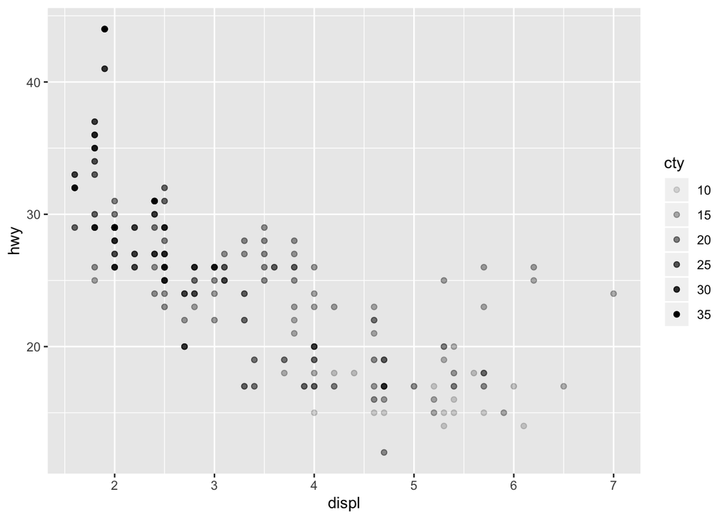

```r
ggplot(data = mpg) +
  geom_point(mapping = aes(x = displ, y = hwy, alpha = cty))
```

- We can change the color to make it a little easier to read:

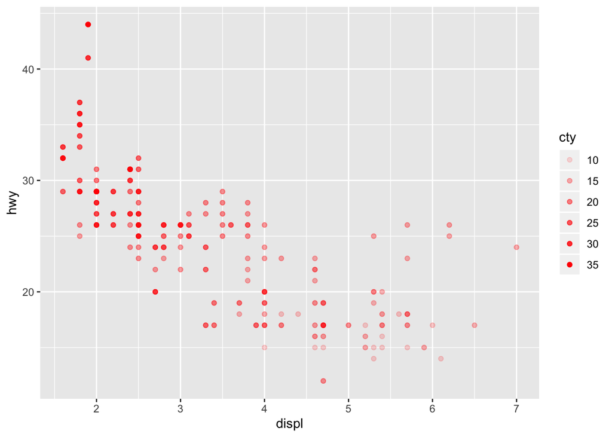

```r
ggplot(data = mpg) +
  geom_point(mapping = aes(x = displ, y = hwy, alpha = cty), color = "red")
```

### Examples

- **Example 1:** What happens if you map the same variable to multiple aesthetics?
- **Example 2:** What does the `stroke` aesthetic do? What shapes does it work with?
- **Example 3:** What happens if you map an aesthetic to something other than a variable name, like `aes(colour = displ < 5)`? Note, you’ll also need to specify x and y.

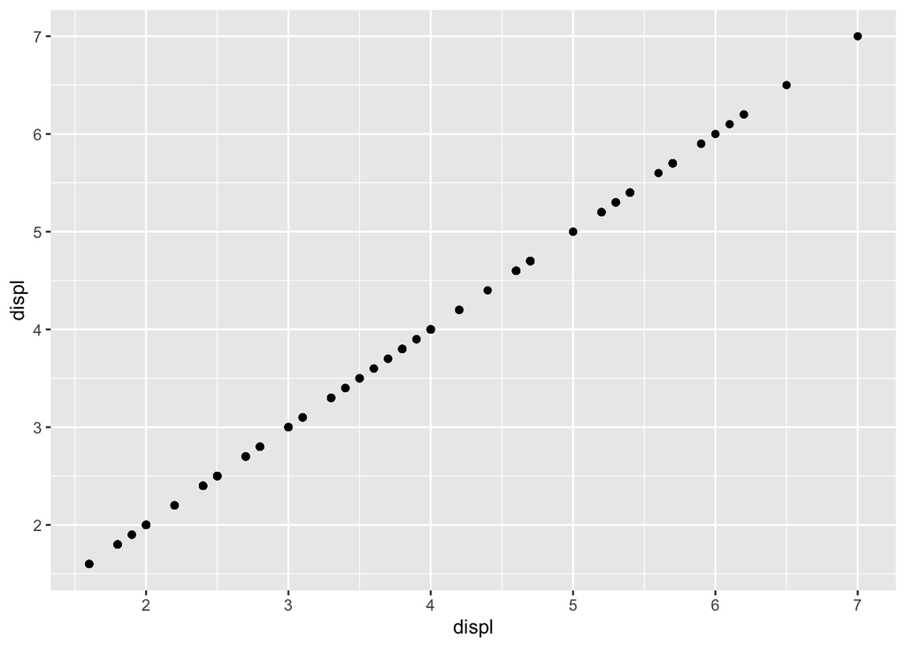

```r
# Example 1
ggplot(data = mpg) +
  geom_point(mapping = aes(x = displ, y = displ))
```

- Plotting the same variable on mutliple aesthetics plots a perfectly linear correlation!

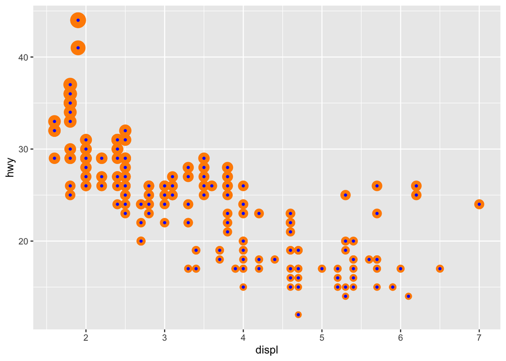

```r
# Example 2
ggplot(data = mpg) +
  geom_point(mapping = aes(x = displ, y = hwy, stroke = hwy/10), shape = 21, color = "darkorange", fill = "blue")
```

- `stroke` controls the size of the outer ring the shapes 21-24. In this example, the stroke is the orange part.

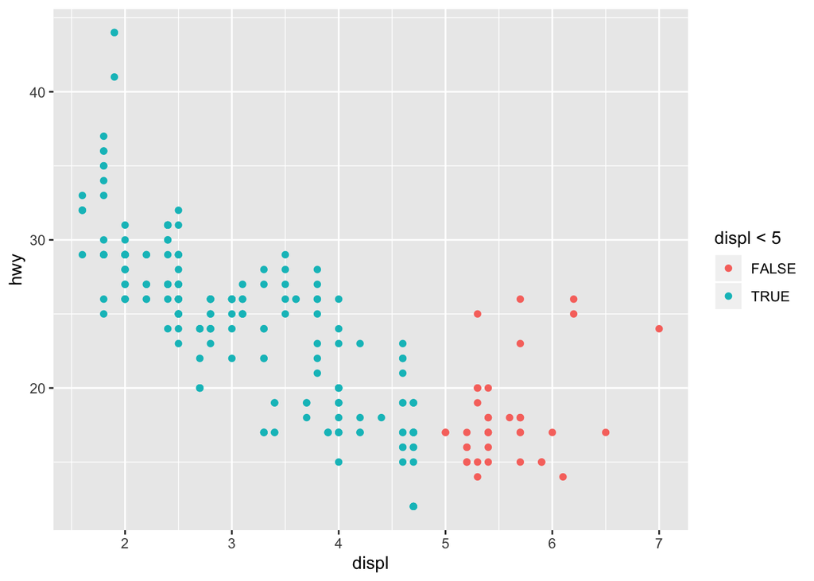

```r
# Example 3
ggplot(data = mpg) +
  geom_point(mapping = aes(x = displ, y = hwy, color = displ < 5))
```

- In this case, the color argument took the boolean argument `displ < 5` and applied a color mapping to the variables depending on whether or not that row met that condition.

## Common Problems

- One common problem when creating graphics using `ggplot2` is putting the `+` in the wrong places
  - It comes at the end of the line, not the start of the next line!